# Assignment 1

# Assignment 2

Use the merged data frame from Assignment 1 for this assignment This Assignment focuses on data preprocessing and model building. Continue with the datasets loaded in Assignment 1 (or reload with same steps and create merged data frame) and Make a stratified 80-20 split based on target to ensure there are no biases in the dataset. Predict the "total_cases" using a stochastic gradient descent regressor. Calculate the Root Mean Square Error. Also, plot Learning Curve for the model. Provide your intepretations based on these metrics.

- Import the required libraries
- Make an 80-20 stratified split based on the target data
- Preprocess the data (Encode the categorical features and Standardize the numerical features)
- Build a stochastic gradient descent regressor, train the model and make predictions using it
- Evaluate your model based on the various metrics stated above
- Plot Learning curve and provide insights

```python
from sklearn import preprocessing
#df_s=pd.DataFrame(preprocessing.scale(df), columns=['AT', 'V','AP','RH','PE'])
#from sklearn.preprocessing import OneHotEncoder
from sklearn.preprocessing import LabelEncoder
le_city = LabelEncoder()
df['city_encoded'] = le_city.fit_transform(df.city)
```

```python
from sklearn.model_selection import train_test_split

X=df_merged.filter(['city_encoded', 'year', 'weekofyear', 'ndvi_ne', 'ndvi_nw','ndvi_se', 'ndvi_sw', 'precipitation_amt_mm',
               'reanalysis_air_tmp_k', 'reanalysis_relative_humidity_percent','reanalysis_sat_precip_amt_mm',
              'reanalysis_specific_humidity_g_per_kg', 'reanalysis_tdtr_k', 'station_avg_tmp_c',
               'station_diur_tmp_rng_c', 'station_max_tmp_c', 'station_min_tmp_c',  'station_precip_mm' ])
y=df_merged.filter(['total_cases'])

X_train, X_test, y_train, y_test=train_test_split(X,y)
```

```python
print(X_train.shape, X_test.shape, y_train.shape, y_test.shape)
```

```
((1092, 17), (364, 17), (1092, 1), (364, 1))
```

```python
import numpy as np
from sklearn.linear_model import SGDRegressor
```

```python
sgd_reg_mdl = linear_model.SGDRegressor(max_iter=1000, tol=1e-3)
```

```python
sgd_reg_mdl.fit(X_train, y_train)
SGDRegressor()
```

```
SGDRegressor(alpha=0.0001, average=False, early_stopping=False, epsilon=0.1,
       eta0=0.01, fit_intercept=True, l1_ratio=0.15,
       learning_rate='invscaling', loss='squared_loss', max_iter=None,
       n_iter=None, n_iter_no_change=5, penalty='l2', power_t=0.25,
       random_state=None, shuffle=True, tol=None, validation_fraction=0.1,
       verbose=0, warm_start=False)
```

```python
y_pred1=sgd_reg_mdl.predict(X_test)
```

```python
from sklearn.metrics import mean_squared_error
from sklearn.metrics import mean_absolute_error


mse1=mean_squared_error(y_test,y_pred1)
print('Mean Squared Error is: ', mse1)
mae1=mean_absolute_error(y_test,y_pred1)
print('Mean Absolute Error is: ', mae1)
```

```
('Mean Squared Error is: ', 3.465046353472365e+29)
('Mean Absolute Error is: ', 578705843913090.8)
```

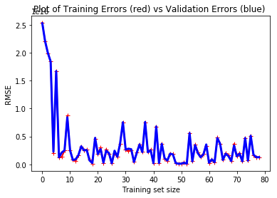

```python
import numpy as np

def plot_learning_curves(model, X, y):
    X_train, X_val, y_train, y_val = train_test_split(X, y, test_size=0.2)
    train_errors, val_errors = [], []
    for m in range(1, len(X_train)):
        model.fit(X_train[:m], y_train[:m])
        y_train_predict = model.predict(X_train[:m])
        y_val_predict = model.predict(X_val)
        train_errors.append(mean_squared_error(y_train_predict, y_train[:m]))
        val_errors.append(mean_squared_error(y_val_predict, y_val))
    plt.plot(np.sqrt(train_errors), "r-+", linewidth=2, label="train")
    plt.plot(np.sqrt(val_errors), "b-", linewidth=3, label="val")
    plt.xlabel('Training set size')
    plt.ylabel('RMSE')
    plt.title('Plot of Training Errors (red) vs Validation Errors (blue) ')

df_merged_sample=df_merged.sample(100)
#print(df_merged_sample.head(3))
#X_sample=df_merged_sample[['AT', 'V', 'AP', 'RH']]
#y_sample=df_merged_sample[['PE']]
#plot_learning_curves(svm_reg2,X_sample, y_sample)

X_sample=df_merged_sample.filter(['city_encoded', 'year', 'weekofyear', 'ndvi_ne', 'ndvi_nw','ndvi_se', 'ndvi_sw', 'precipitation_amt_mm',
               'reanalysis_air_tmp_k', 'reanalysis_relative_humidity_percent','reanalysis_sat_precip_amt_mm',
              'reanalysis_specific_humidity_g_per_kg', 'reanalysis_tdtr_k', 'station_avg_tmp_c',
               'station_diur_tmp_rng_c', 'station_max_tmp_c', 'station_min_tmp_c',  'station_precip_mm' ])
y_sample=df_merged_sample.filter(['total_cases'])
plot_learning_curves(sgd_reg_mdl,X_sample, y_sample)
```

# Assignment 3

1. Load the same data set as before in Assignment 1 and 2 and create the merged data set
2. Visualize the distribution of each key attibute
3. Split the data into training and test sets
4. For the support vector models to perform better, scale the data (if it is required)
5. Build a linear SVR model and analyse its performances
6. Build a SVR model with a linear kernel and compare its performances with the Linear SVR model
7. Using a sample from the original data, plot a learning curve for the SVR model and interpret the results

Create a model that has high accuracy. The contest in the linke above accepts submission of results in prescribed format. You can refine, combine the best performing criteria from your models and submit as team

```python
from sklearn import preprocessing

#df_s=pd.DataFrame(preprocessing.scale(df), columns=['AT', 'V','AP','RH','PE'])
```

```python
#from sklearn.preprocessing import OneHotEncoder
from sklearn.preprocessing import LabelEncoder
le_city = LabelEncoder()
df['city_encoded'] = le_city.fit_transform(df.city)
```

```python
from sklearn.model_selection import train_test_split

X=df_merged.filter(['city_encoded', 'year', 'weekofyear', 'ndvi_ne', 'ndvi_nw','ndvi_se', 'ndvi_sw', 'precipitation_amt_mm',
               'reanalysis_air_tmp_k', 'reanalysis_relative_humidity_percent','reanalysis_sat_precip_amt_mm',
              'reanalysis_specific_humidity_g_per_kg', 'reanalysis_tdtr_k', 'station_avg_tmp_c',
               'station_diur_tmp_rng_c', 'station_max_tmp_c', 'station_min_tmp_c',  'station_precip_mm' ])
y=df_merged.filter(['total_cases'])

X_train, X_test, y_train, y_test=train_test_split(X,y)
```

```python
print(X_train.shape, X_test.shape, y_train.shape, y_test.shape)
```

```
((1092, 17), (364, 17), (1092, 1), (364, 1))
```

```python
from sklearn.svm import LinearSVR

svm_reg1=LinearSVR(epsilon=0.05)
svm_reg1.fit(X_train, y_train)
y_pred1=svm_reg1.predict(X_test)
```

```python
from sklearn.metrics import mean_squared_error
from sklearn.metrics import mean_absolute_error


mse1=mean_squared_error(y_test,y_pred1)
print(mse1)
mae1=mean_absolute_error(y_test,y_pred1)
print(mae1)
```

```
1817.693159288896
21.633215726696392
```

```python
from sklearn.svm import SVR

svm_reg2=SVR(kernel='linear', epsilon=0.05)
svm_reg2.fit(X_train, y_train)
y_pred2=svm_reg2.predict(X_test)

mse2=mean_squared_error(y_test,y_pred2)
print('Mean Squared Error is: ', mse2)
mae2=mean_absolute_error(y_test,y_pred2)
print('Mean Absolute Error is: ', mae1)
```

[output not shown]

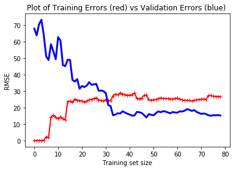

```python
import numpy as np

def plot_learning_curves(model, X, y):
    X_train, X_val, y_train, y_val = train_test_split(X, y, test_size=0.2)
    train_errors, val_errors = [], []
    for m in range(1, len(X_train)):
        model.fit(X_train[:m], y_train[:m])
        y_train_predict = model.predict(X_train[:m])
        y_val_predict = model.predict(X_val)
        train_errors.append(mean_squared_error(y_train_predict, y_train[:m]))
        val_errors.append(mean_squared_error(y_val_predict, y_val))
    plt.plot(np.sqrt(train_errors), "r-+", linewidth=2, label="train")
    plt.plot(np.sqrt(val_errors), "b-", linewidth=3, label="val")
    plt.xlabel('Training set size')
    plt.ylabel('RMSE')
    plt.title('Plot of Training Errors (red) vs Validation Errors (blue) ')

df_merged_sample=df_merged.sample(100)
#print(df_merged_sample.head(3))
#X_sample=df_merged_sample[['AT', 'V', 'AP', 'RH']]
#y_sample=df_merged_sample[['PE']]
#plot_learning_curves(svm_reg2,X_sample, y_sample)

X_sample=df_merged_sample.filter(['city_encoded', 'year', 'weekofyear', 'ndvi_ne', 'ndvi_nw','ndvi_se', 'ndvi_sw', 'precipitation_amt_mm',
               'reanalysis_air_tmp_k', 'reanalysis_relative_humidity_percent','reanalysis_sat_precip_amt_mm',
              'reanalysis_specific_humidity_g_per_kg', 'reanalysis_tdtr_k', 'station_avg_tmp_c',
               'station_diur_tmp_rng_c', 'station_max_tmp_c', 'station_min_tmp_c',  'station_precip_mm' ])
y_sample=df_merged_sample.filter(['total_cases'])
plot_learning_curves(svm_reg2,X_sample, y_sample)
```